# Credit Card Analysis

## Introduction

In this short project i will be analyzing a sample of Credit card transaction data found in [**Kaggle**](https://www.kaggle.com/datasets/e47f88e5e8ce59c9598475a107d9a80ebc363a83859a59facb069b13a9001773?select=cc_sample_transaction.json) utilizing Pyspark to extract, transform and Load the datasets and using these data to provide meaningful insights and findings

- Objective: Analyze and visualize credit card transaction data using PySpark.

## Setup (Importing packages required)

start by intalling, loading importing the necessary packages needed the analysis

```python
from pyspark.sql import SparkSession
from pyspark.sql.functions import *
from pyspark.sql.types import *
import matplotlib.pyplot as plt
import seaborn as sns
import pandas as pd
import hashlib
```

## Creating a SparkSession

```python
spark = SparkSession.builder.appName("C\\Users\\ccalv\\Desktop\\Paynet Assessment\\cc_sample_transaction.json").getOrCreate()
print("Spark version:", spark.version)
```

```
Spark version: 4.0.0
```

## reading the dataset and checking row count to make sure data is properly loaded

```python
df = spark.read.json("C:/Users/ccalv/Desktop/Paynet Assessment/cc_sample_transaction.json")

print("Row count:", df.count())
```

```
Row count: 1296675
```

to get a glimpse of the raw data before doing any transformation and cleaning

```python
json_file_path = r"C:\Users\ccalv\Desktop\Paynet Assessment\cc_sample_transaction.json"
raw_json_df = spark.read.text(json_file_path)
raw_json_df.show(truncate=False)
```

```
+-----------------------------------------------------------------------------------------------------------------------------------------------------------------------------------------------------------------------------------------------------------------------------------------------------------…
|value                                                                                                                                                                                                                                                                                                      …
+-----------------------------------------------------------------------------------------------------------------------------------------------------------------------------------------------------------------------------------------------------------------------------------------------------------…
|{"Unnamed: 0":"0","trans_date_trans_time":"2019-01-01 00:00:18","cc_bic":"CITIUS33CHI","cc_num":"2703186189652095","merchant":"fraud_Rippin, Kub and Mann","category":"misc_net","amt":"4.97","personal_detail":"{\"person_name\":\"Jennifer,Banks,eeeee\",\"gender\":\"F\",\"address\":\"{\\\"street\\\":\…
|{"Unnamed: 0":"1","trans_date_trans_time":"2019-01-01 00:00:44","cc_bic":"ADMDUS41","cc_num":"630423337322","merchant":"fraud_Heller, Gutmann and Zieme","category":"grocery_pos","amt":"107.23","personal_detail":"{\"person_name\":\"Stephanie,Gill,eeeee\",\"gender\":\"F\",\"address\":\"{\\\"street\\\…
|{"Unnamed: 0":"2","trans_date_trans_time":"2019-01-01 00:00:51","cc_bic":"Null","cc_num":"38859492057661","merchant":"fraud_Lind-Buckridge","category":"entertainment","amt":"220.11","personal_detail":"{\"person_name\":\"Edward@Sanchez\",\"gender\":\"M\",\"address\":\"{\\\"street\\\":\\\"594 White D…
|{"Unnamed: 0":"3","trans_date_trans_time":"2019-01-01 00:01:16","cc_bic":"DEUTUS33TRF","cc_num":"3534093764340240","merchant":"fraud_Kutch, Hermiston and Farrell","category":"gas_transport","amt":"45.0","personal_detail":"{\"person_name\":\"Jeremy/White, !\",\"gender\":\"M\",\"address\":\"{\\\"stre…
|{"Unnamed: 0":"4","trans_date_trans_time":"2019-01-01 00:03:06","cc_bic":"APBCUS61","cc_num":"375534208663984","merchant":"fraud_Keeling-Crist","category":"misc_pos","amt":"41.96","personal_detail":"{\"person_name\":\"Tyler@Garcia\",\"gender\":\"M\",\"address\":\"{\\\"street\\\":\\\"408 Bradley Res…
|{"Unnamed: 0":"5","trans_date_trans_time":"2019-01-01 00:04:08","cc_bic":"APBCUS61","cc_num":"4767265376804500","merchant":"fraud_Stroman, Hudson and Erdman","category":"gas_transport","amt":"94.63","personal_detail":"{\"person_name\":\"Jennifer,Conner,eeeee\",\"gender\":\"F\",\"address\":\"{\\\"st…
|{"Unnamed: 0":"6","trans_date_trans_time":"2019-01-01 00:04:42","cc_bic":"APBCUS61","cc_num":"30074693890476","merchant":"fraud_Rowe-Vandervort","category":"grocery_net","amt":"44.54","personal_detail":"{\"person_name\":\"Kelsey, , Richards NOOOO\",\"gender\":\"F\",\"address\":\"{\\\"street\\\":\\\…
|{"Unnamed: 0":"7","trans_date_trans_time":"2019-01-01 00:05:08","cc_bic":"NA","cc_num":"6011360759745864","merchant":"fraud_Corwin-Collins","category":"gas_transport","amt":"71.65","personal_detail":"{\"person_name\":\"Steven, Williams\",\"gender\":\"M\",\"address\":\"{\\\"street\\\":\\\"231 Flores…
|{"Unnamed: 0":"8","trans_date_trans_time":"2019-01-01 00:05:18","cc_bic":"ACEEUS31","cc_num":"4922710831011201","merchant":"fraud_Herzog Ltd","category":"misc_pos","amt":"4.27","personal_detail":"{\"person_name\":\"Heather, , Chase NOOOO\",\"gender\":\"F\",\"address\":\"{\\\"street\\\":\\\"6888 Hic…
|{"Unnamed: 0":"9","trans_date_trans_time":"2019-01-01 00:06:01","cc_bic":"DEUTUS33TRF","cc_num":"2720830304681674","merchant":"fraud_Schoen, Kuphal and Nitzsche","category":"grocery_pos","amt":"198.39","personal_detail":"{\"person_name\":\"Melissa@Aguilar\",\"gender\":\"F\",\"address\":\"{\\\"stree…
|{"Unnamed: 0":"10","trans_date_trans_time":"2019-01-01 00:06:23","cc_bic":"","cc_num":"4642894980163","merchant":"fraud_Rutherford-Mertz","category":"grocery_pos","amt":"24.74","personal_detail":"{\"person_name\":\"Eddie|Mendez!!!\",\"gender\":\"M\",\"address\":\"{\\\"street\\\":\\\"1831 Faith View…
|{"Unnamed: 0":"11","trans_date_trans_time":"2019-01-01 00:06:53","cc_bic":"DEUTUS33TRF","cc_num":"377234009633447","merchant":"fraud_Kerluke-Abshire","category":"shopping_net","amt":"7.77","personal_detail":"{\"person_name\":\"Theresa@Blackwell\",\"gender\":\"F\",\"address\":\"{\\\"street\\\":\\\"4…
|{"Unnamed: 0":"12","trans_date_trans_time":"2019-01-01 00:06:56","cc_bic":"DEUTUS33TRF","cc_num":"180042946491150","merchant":"fraud_Lockman Ltd","category":"grocery_pos","amt":"71.22","personal_detail":"{\"person_name\":\"Charles|Robles!!!\",\"gender\":\"M\",\"address\":\"{\\\"street\\\":\\\"3337 …
```

[output cut: 9 more lines]

## Load and explore the JSON Dataset

```python
json_file_path = r"C:\Users\ccalv\Desktop\Paynet Assessment\cc_sample_transaction.json"
df = spark.read.option("multiline", "true").json(json_file_path)

df.printSchema()
df.show(truncate=False)
```

```
root
 |-- Unnamed: 0: string (nullable = true)
 |-- amt: string (nullable = true)
 |-- category: string (nullable = true)
 |-- cc_bic: string (nullable = true)
 |-- cc_num: string (nullable = true)
 |-- is_fraud: string (nullable = true)
 |-- merch_eff_time: string (nullable = true)
 |-- merch_last_update_time: string (nullable = true)
 |-- merch_lat: string (nullable = true)
 |-- merch_long: string (nullable = true)
 |-- merch_zipcode: string (nullable = true)
 |-- merchant: string (nullable = true)
 |-- personal_detail: string (nullable = true)
 |-- trans_date_trans_time: string (nullable = true)
 |-- trans_num: string (nullable = true)

+----------+----+--------+-----------+----------------+--------+----------------+----------------------+---------+----------+-------------+--------------------------+--------------------------------------------------------------------------------------------------------------------------------------…
|Unnamed: 0|amt |category|cc_bic     |cc_num          |is_fraud|merch_eff_time  |merch_last_update_time|merch_lat|merch_long|merch_zipcode|merchant                  |personal_detail                                                                                                                       …
+----------+----+--------+-----------+----------------+--------+----------------+----------------------+---------+----------+-------------+--------------------------+--------------------------------------------------------------------------------------------------------------------------------------…
|0         |4.97|misc_net|CITIUS33CHI|2703186189652095|0       |1325376018798532|1325376018666         |36.011293|-82.048315|28705        |fraud_Rippin, Kub and Mann|{"person_name":"Jennifer,Banks,eeeee","gender":"F","address":"{\"street\":\"561 Perry Cove\",\"city\":\"Moravian Falls\",\"state\":\"N…
+----------+----+--------+-----------+----------------+--------+----------------+----------------------+---------+----------+-------------+--------------------------+--------------------------------------------------------------------------------------------------------------------------------------…
```

## Data transformation and Cleaning

```python
df.printSchema()
```

```
root
 |-- Unnamed: 0: string (nullable = true)
 |-- amt: string (nullable = true)
 |-- category: string (nullable = true)
 |-- cc_bic: string (nullable = true)
 |-- cc_num: string (nullable = true)
 |-- is_fraud: string (nullable = true)
 |-- merch_eff_time: string (nullable = true)
 |-- merch_last_update_time: string (nullable = true)
 |-- merch_lat: string (nullable = true)
 |-- merch_long: string (nullable = true)
 |-- merch_zipcode: string (nullable = true)
 |-- merchant: string (nullable = true)
 |-- personal_detail: string (nullable = true)
 |-- trans_date_trans_time: string (nullable = true)
 |-- trans_num: string (nullable = true)
```

### (a) Flatten JSON Structure (if needed)

```python
from pyspark.sql.functions import from_json, col, split, trim
from pyspark.sql.types import StructType, StructField, StringType, DoubleType, IntegerType

# Schema for top-level personal_detail JSON (note address is a JSON string)
personal_detail_schema = StructType([
    StructField("person_name", StringType(), True),
    StructField("gender", StringType(), True),
    StructField("address", StringType(), True),  # nested JSON string
    StructField("lat", StringType(), True),
    StructField("long", StringType(), True),
    StructField("city_pop", StringType(), True),
    StructField("job", StringType(), True),
    StructField("dob", StringType(), True)
])

# Schema for the nested address JSON string
address_schema = StructType([
    StructField("street", StringType(), True),
    StructField("city", StringType(), True),
    StructField("state", StringType(), True),
    StructField("zip", StringType(), True)
])

if "personal_detail" in df.columns:
    df = df.withColumn("personal_detail_struct", from_json(col("personal_detail"), personal_detail_schema))

    df = df.withColumn("person_name", col("personal_detail_struct.person_name")) \
           .withColumn("gender", col("personal_detail_struct.gender")) \
           .withColumn("address_json", col("personal_detail_struct.address")) \
           .withColumn("lat", col("personal_detail_struct.lat").cast("double")) \
           .withColumn("long", col("personal_detail_struct.long").cast("double")) \
           .withColumn("city_pop", col("personal_detail_struct.city_pop").cast("int")) \
           .withColumn("job", col("personal_detail_struct.job")) \
           .withColumn("dob", col("personal_detail_struct.dob"))

    # Parse the nested address JSON string
    df = df.withColumn("address_struct", from_json(col("address_json"), address_schema)) \
           .withColumn("street", col("address_struct.street")) \
           .withColumn("city", col("address_struct.city")) \
           .withColumn("state", col("address_struct.state")) \
           .withColumn("zip", col("address_struct.zip"))

    # Split person_name into first and last names
    df = df.withColumn("first", trim(split(col("person_name"), ",").getItem(0))) \
           .withColumn("last", trim(split(col("person_name"), ",").getItem(1)))

    # Drop intermediate columns no longer needed
    df = df.drop("personal_detail", "personal_detail_struct", "address_json", "address_struct", "person_name")

# Rename hashed cc_num column if needed
if "cc_num_hashed" in df.columns:
    df = df.withColumnRenamed("cc_num_hashed", "cc_num")

expected_columns = [
    "Unnamed: 0", "amt", "category", "cc_bic", "is_fraud", "merch_eff_time",
    "merch_last_update_time", "merch_lat", "merch_long", "merch_zipcode", "merchant",
    "trans_date_trans_time", "trans_num", "cc_num", "first", "last", "gender",
    "street", "city", "state", "zip", "lat", "long", "city_pop", "job", "dob"
]

df = df.select(*expected_columns)
df.show(50, truncate=False)
```

```
+----------+----+--------+-----------+--------+----------------+----------------------+---------+----------+-------------+--------------------------+---------------------+--------------------------------+----------------+--------+-----+------+--------------+--------------+-----+-----+-------+-------…
|Unnamed: 0|amt |category|cc_bic     |is_fraud|merch_eff_time  |merch_last_update_time|merch_lat|merch_long|merch_zipcode|merchant                  |trans_date_trans_time|trans_num                       |cc_num          |first   |last |gender|street        |city          |state|zip  |lat    |long   …
+----------+----+--------+-----------+--------+----------------+----------------------+---------+----------+-------------+--------------------------+---------------------+--------------------------------+----------------+--------+-----+------+--------------+--------------+-----+-----+-------+-------…
|0         |4.97|misc_net|CITIUS33CHI|0       |1325376018798532|1325376018666         |36.011293|-82.048315|28705        |fraud_Rippin, Kub and Mann|2019-01-01 00:00:18  |0b242abb623afc578575680df30655b9|2703186189652095|Jennifer|Banks|F     |561 Perry Cove|Moravian Falls|NC   |28654|36.0788|-81.178…
+----------+----+--------+-----------+--------+----------------+----------------------+---------+----------+-------------+--------------------------+---------------------+--------------------------------+----------------+--------+-----+------+--------------+--------------+-----+-----+-------+-------…
```

i checked the JSON file structure using the above code to identify whether JSON Flattening is required and found that

Most fields are simple strings — no nested struct or array types are shown except the personal_Details section. So i did JSON Flattening for the Personal_Details section Why and How I Flattened the JSON personal_detail Field The dataset originally stored customer information (like name, address, and demographics) inside a single column called personal_detail, which contained JSON-formatted strings. This structure made it difficult to access or analyze individual pieces of data, such as the customer's city, gender, or date of birth.

To solve this, I flattened the JSON by:

Parsing the JSON string into a structured format (StructType) using from_json().

I also extracted the person_name column (e.g., first, last, gender, etc.) into its own column using withColumn().

This process made the dataset cleaner, more readable, and easier to work with for further analysis, filtering, and visualization.

#### run df.printSchema() above again after flattening the JSON dataset the personal_Details Column will change to the expected columns desired as mentioned in the PDF

### (c) Timestamp Conversion: All time-related columns

after converting all the time-relatd columns below to timestamp from String

i also dropped unwanted columns

```python
df.printSchema()
```

```
root
 |-- Unnamed: 0: string (nullable = true)
 |-- amt: string (nullable = true)
 |-- category: string (nullable = true)
 |-- cc_bic: string (nullable = true)
 |-- is_fraud: string (nullable = true)
 |-- merch_eff_time: string (nullable = true)
 |-- merch_last_update_time: string (nullable = true)
 |-- merch_lat: string (nullable = true)
 |-- merch_long: string (nullable = true)
 |-- merch_zipcode: string (nullable = true)
 |-- merchant: string (nullable = true)
 |-- trans_date_trans_time: string (nullable = true)
 |-- trans_num: string (nullable = true)
 |-- cc_num: string (nullable = true)
 |-- first: string (nullable = true)
 |-- last: string (nullable = true)
 |-- gender: string (nullable = true)
 |-- street: string (nullable = true)
 |-- city: string (nullable = true)
 |-- state: string (nullable = true)
 |-- zip: string (nullable = true)
 |-- lat: double (nullable = true)
 |-- long: double (nullable = true)
 |-- city_pop: integer (nullable = true)
 |-- job: string (nullable = true)
 |-- dob: string (nullable = true)
```

```python
from pyspark.sql.functions import to_timestamp, col

df = df.withColumn("merch_last_update_time", to_timestamp(col("merch_last_update_time")))
df = df.withColumn("merch_eff_time", to_timestamp(col("merch_eff_time")))
df = df.withColumn("trans_date_trans_time", to_timestamp(col("trans_date_trans_time")))

#run df.printSchema() above to check if the time-related columns format has been change to timestamp from String previously
# if neccessary run df = df.drop(*columns_to_drop) to srop any duplicate or unwanted columns
```

### (d) Name Derivation: Extract first and last name columns from person_name

```python
df.printSchema()
print(df.columns)
```

```
root
 |-- Unnamed: 0: string (nullable = true)
 |-- amt: string (nullable = true)
 |-- category: string (nullable = true)
 |-- cc_bic: string (nullable = true)
 |-- is_fraud: string (nullable = true)
 |-- merch_eff_time: timestamp (nullable = true)
 |-- merch_last_update_time: timestamp (nullable = true)
 |-- merch_lat: string (nullable = true)
 |-- merch_long: string (nullable = true)
 |-- merch_zipcode: string (nullable = true)
 |-- merchant: string (nullable = true)
 |-- trans_date_trans_time: timestamp (nullable = true)
 |-- trans_num: string (nullable = true)
 |-- cc_num: string (nullable = true)
 |-- first: string (nullable = true)
 |-- last: string (nullable = true)
 |-- gender: string (nullable = true)
 |-- street: string (nullable = true)
 |-- city: string (nullable = true)
 |-- state: string (nullable = true)
 |-- zip: string (nullable = true)
 |-- lat: double (nullable = true)
 |-- long: double (nullable = true)
 |-- city_pop: integer (nullable = true)
 |-- job: string (nullable = true)
 |-- dob: string (nullable = true)

['Unnamed: 0', 'amt', 'category', 'cc_bic', 'is_fraud', 'merch_eff_time', 'merch_last_update_time', 'merch_lat', 'merch_long', 'merch_zipcode', 'merchant', 'trans_date_trans_time', 'trans_num', 'cc_num', 'first', 'last', 'gender', 'street', 'city', 'state', 'zip', 'lat', 'long', 'city_pop', 'job', '…
```

```python
df = spark.read.json("C:/Users/ccalv/Desktop/Paynet Assessment/cc_sample_transaction.json")

print("Row count:", df.count())
```

```
Row count: 1296675
```

```python
from pyspark.sql.functions import col, from_json, trim, split
from pyspark.sql.types import StructType, StructField, StringType

# Define the JSON schema for personal_detail
personal_detail_schema = StructType([
    StructField("person_name", StringType(), True),
    StructField("gender", StringType(), True),
    StructField("address", StringType(), True),
    StructField("lat", StringType(), True),
    StructField("long", StringType(), True),
    StructField("city_pop", StringType(), True),
    StructField("job", StringType(), True),
    StructField("dob", StringType(), True),
])

# Parse the JSON string into a struct
df = df.withColumn("personal_detail_parsed", from_json(col("personal_detail"), personal_detail_schema))
```

```python
from pyspark.sql.functions import regexp_replace, trim, col, split, when

# Step 1: Replace known separators with comma
df = df.withColumn(
    "cleaned_name",
    regexp_replace(col("personal_detail_parsed.person_name"), r"[@/!|]", ",")
)

# Step 2: Replace multiple commas with a single comma
df = df.withColumn(
    "cleaned_name",
    regexp_replace(col("cleaned_name"), r",+", ",")
)

# Step 3: Remove unwanted patterns (case-insensitive)
df = df.withColumn(
    "cleaned_name",
    regexp_replace(col("cleaned_name"), r"(?i)\b(ee+|null|no+|yes+|garbage|na+|none)\b", "")
)

# Step 4: Remove digits
df = df.withColumn(
    "cleaned_name",
    regexp_replace(col("cleaned_name"), r"\d+", "")
)

# Step 5: Remove extra non-letter characters (except comma and space)
df = df.withColumn(
    "cleaned_name",
    regexp_replace(col("cleaned_name"), r"[^A-Za-z, ]", "")
)

# Step 6: Clean up any leftover multiple commas or spaces again
df = df.withColumn(
    "cleaned_name",
    regexp_replace(col("cleaned_name"), r",+", ",")
)
df = df.withColumn(
    "cleaned_name",
    regexp_replace(col("cleaned_name"), r"(^,|,$)", "")
)
df = df.withColumn("cleaned_name", trim(col("cleaned_name")))
```

```python
from pyspark.sql.functions import col, split, trim

# Split directly from personal_detail string
df = df.withColumn("first", trim(split(col("personal_detail"), ",").getItem(0)))
df = df.withColumn("last", trim(split(col("personal_detail"), ",").getItem(1)))

# Show the result
df.select("personal_detail", "first", "last").show(50, truncate=False)
```

```
+----------------------------------------------------------------------------------------------------------------------------------------------------------------------------------------------------------------------------------------------------------------------------------------+------------------…
|personal_detail                                                                                                                                                                                                                                                                         |first             …
+----------------------------------------------------------------------------------------------------------------------------------------------------------------------------------------------------------------------------------------------------------------------------------------+------------------…
|{"person_name":"Jennifer,Banks,eeeee","gender":"F","address":"{\"street\":\"561 Perry Cove\",\"city\":\"Moravian Falls\",\"state\":\"NC\",\"zip\":\"28654\"}","lat":"36.0788","long":"-81.1781","city_pop":"3495","job":"Psychologist, counselling","dob":"1988-03-09"}                 |{"person_name":"Je…
|{"person_name":"Stephanie,Gill,eeeee","gender":"F","address":"{\"street\":\"43039 Riley Greens Suite 393\",\"city\":\"Orient\",\"state\":\"WA\",\"zip\":\"99160\"}","lat":"48.8878","long":"-118.2105","city_pop":"149","job":"Special educational needs teacher","dob":"1978-06-21"}   |{"person_name":"St…
|{"person_name":"Edward@Sanchez","gender":"M","address":"{\"street\":\"594 White Dale Suite 530\",\"city\":\"Malad City\",\"state\":\"ID\",\"zip\":\"83252\"}","lat":"42.1808","long":"-112.262","city_pop":"4154","job":"Nature conservation officer","dob":"1962-01-19"}               |{"person_name":"Ed…
|{"person_name":"Jeremy/White, !","gender":"M","address":"{\"street\":\"9443 Cynthia Court Apt. 038\",\"city\":\"Boulder\",\"state\":\"MT\",\"zip\":\"59632\"}","lat":"46.2306","long":"-112.1138","city_pop":"1939","job":"Patent attorney","dob":"1967-01-12"}                         |{"person_name":"Je…
|{"person_name":"Tyler@Garcia","gender":"M","address":"{\"street\":\"408 Bradley Rest\",\"city\":\"Doe Hill\",\"state\":\"VA\",\"zip\":\"24433\"}","lat":"38.4207","long":"-79.4629","city_pop":"99","job":"Dance movement psychotherapist","dob":"1986-03-28"}                          |{"person_name":"Ty…
|{"person_name":"Jennifer,Conner,eeeee","gender":"F","address":"{\"street\":\"4655 David Island\",\"city\":\"Dublin\",\"state\":\"PA\",\"zip\":\"18917\"}","lat":"40.375","long":"-75.2045","city_pop":"2158","job":"Transport planner","dob":"1961-06-19"}                              |{"person_name":"Je…
|{"person_name":"Kelsey, , Richards NOOOO","gender":"F","address":"{\"street\":\"889 Sarah Station Suite 624\",\"city\":\"Holcomb\",\"state\":\"KS\",\"zip\":\"67851\"}","lat":"37.9931","long":"-100.9893","city_pop":"2691","job":"Arboriculturist","dob":"1993-08-16"}                |{"person_name":"Ke…
|{"person_name":"Steven, Williams","gender":"M","address":"{\"street\":\"231 Flores Pass Suite 720\",\"city\":\"Edinburg\",\"state\":\"VA\",\"zip\":\"22824\"}","lat":"38.8432","long":"-78.6003","city_pop":"6018","job":"Designer, multimedia","dob":"1947-08-21"}                     |{"person_name":"St…
|{"person_name":"Heather, , Chase NOOOO","gender":"F","address":"{\"street\":\"6888 Hicks Stream Suite 954\",\"city\":\"Manor\",\"state\":\"PA\",\"zip\":\"15665\"}","lat":"40.3359","long":"-79.6607","city_pop":"1472","job":"Public affairs consultant","dob":"1941-03-07"}           |{"person_name":"He…
|{"person_name":"Melissa@Aguilar","gender":"F","address":"{\"street\":\"21326 Taylor Squares Suite 708\",\"city\":\"Clarksville\",\"state\":\"TN\",\"zip\":\"37040\"}","lat":"36.522","long":"-87.34899999999999","city_pop":"151785","job":"Pathologist","dob":"1974-03-28"}            |{"person_name":"Me…
|{"person_name":"Eddie|Mendez!!!","gender":"M","address":"{\"street\":\"1831 Faith View Suite 653\",\"city\":\"Clarinda\",\"state\":\"IA\",\"zip\":\"51632\"}","lat":"40.7491","long":"-95.038","city_pop":"7297","job":"IT trainer","dob":"1990-07-13"}                                 |{"person_name":"Ed…
|{"person_name":"Theresa@Blackwell","gender":"F","address":"{\"street\":\"43576 Kristina Islands\",\"city\":\"Shenandoah Junction\",\"state\":\"WV\",\"zip\":\"25442\"}","lat":"39.3716","long":"-77.8229","city_pop":"1925","job":"Systems developer","dob":"1966-02-14"}               |{"person_name":"Th…
|{"person_name":"Charles|Robles!!!","gender":"M","address":"{\"street\":\"3337 Lisa Divide\",\"city\":\"Saint Petersburg\",\"state\":\"FL\",\"zip\":\"33710\"}","lat":"27.7898","long":"-82.7243","city_pop":"341043","job":"Engineer, land","dob":"1989-02-28"}                         |{"person_name":"Ch…
```

[output cut: 39 more lines]

```python
df.select("personal_detail_parsed.person_name", "cleaned_name", "first", "last").show(50,truncate=False)
```

```
+-------------------------+---------------------+--------------------------------------+------------+
|person_name              |cleaned_name         |first                                 |last        |
+-------------------------+---------------------+--------------------------------------+------------+
|Jennifer,Banks,eeeee     |Jennifer,Banks       |{"person_name":"Jennifer              |Banks       |
|Stephanie,Gill,eeeee     |Stephanie,Gill       |{"person_name":"Stephanie             |Gill        |
|Edward@Sanchez           |Edward,Sanchez       |{"person_name":"Edward@Sanchez"       |"gender":"M"|
|Jeremy/White, !          |Jeremy,White,        |{"person_name":"Jeremy/White          |!"          |
|Tyler@Garcia             |Tyler,Garcia         |{"person_name":"Tyler@Garcia"         |"gender":"M"|
|Jennifer,Conner,eeeee    |Jennifer,Conner      |{"person_name":"Jennifer              |Conner      |
|Kelsey, , Richards NOOOO |Kelsey, , Richards   |{"person_name":"Kelsey                |            |
|Steven, Williams         |Steven, Williams     |{"person_name":"Steven                |Williams"   |
|Heather, , Chase NOOOO   |Heather, , Chase     |{"person_name":"Heather               |            |
|Melissa@Aguilar          |Melissa,Aguilar      |{"person_name":"Melissa@Aguilar"      |"gender":"F"|
|Eddie|Mendez!!!          |Eddie,Mendez         |{"person_name":"Eddie|Mendez!!!"      |"gender":"M"|
|Theresa@Blackwell        |Theresa,Blackwell    |{"person_name":"Theresa@Blackwell"    |"gender":"F"|
|Charles|Robles!!!        |Charles,Robles       |{"person_name":"Charles|Robles!!!"    |"gender":"M"|
|Jack@Hill                |Jack,Hill            |{"person_name":"Jack@Hill"            |"gender":"M"|
|Christopher@Castaneda    |Christopher,Castaneda|{"person_name":"Christopher@Castaneda"|"gender":"M"|
|Ronald@Carson            |Ronald,Carson        |{"person_name":"Ronald@Carson"        |"gender":"M"|
|Lisa, Mendez             |Lisa, Mendez         |{"person_name":"Lisa                  |Mendez"     |
|Nathan,Thomas,eeeee      |Nathan,Thomas        |{"person_name":"Nathan                |Thomas      |
|Justin, Gay              |Justin, Gay          |{"person_name":"Justin                |Gay"        |
|Kenneth, , Robinson NOOOO|Kenneth, , Robinson  |{"person_name":"Kenneth               |            |
|Gregory|Graham!!!        |Gregory,Graham       |{"person_name":"Gregory|Graham!!!"    |"gender":"M"|
|Jeffrey@Rice             |Jeffrey,Rice         |{"person_name":"Jeffrey@Rice"         |"gender":"M"|
|Mary,Wall,eeeee          |Mary,Wall            |{"person_name":"Mary                  |Wall        |
|Susan, , Washington NOOOO|Susan, , Washington  |{"person_name":"Susan                 |            |
|Richard@Waters           |Richard,Waters       |{"person_name":"Richard@Waters"       |"gender":"M"|
|Jodi/Foster, !           |Jodi,Foster,         |{"person_name":"Jodi/Foster           |!"          |
|Daniel/Escobar, !        |Daniel,Escobar,      |{"person_name":"Daniel/Escobar        |!"          |
|Scott/Martin, !          |Scott,Martin,        |{"person_name":"Scott/Martin          |!"          |
|Brian@Simpson            |Brian,Simpson        |{"person_name":"Brian@Simpson"        |"gender":"M"|
|Aaron@Rogers             |Aaron,Rogers         |{"person_name":"Aaron@Rogers"         |"gender":"M"|
|Tammie@Harper            |Tammie,Harper        |{"person_name":"Tammie@Harper"        |"gender":"F"|
|Mary/Myers, !            |Mary,Myers,          |{"person_name":"Mary/Myers            |!"          |
|Heather@Stanton          |Heather,Stanton      |{"person_name":"Heather@Stanton"      |"gender":"F"|
|Jenna,Brooks,eeeee       |Jenna,Brooks         |{"person_name":"Jenna                 |Brooks      |
|Christopher@Gilbert      |Christopher,Gilbert  |{"person_name":"Christopher@Gilbert"  |"gender":"M"|
|Xavier, , Beltran NOOOO  |Xavier, , Beltran    |{"person_name":"Xavier                |            |
|Ashley, Lopez            |Ashley, Lopez        |{"person_name":"Ashley                |Lopez"      |
|Margaret|Curtis!!!       |Margaret,Curtis      |{"person_name":"Margaret|Curtis!!!"   |"gender":"F"|
|Gina, Morrison           |Gina, Morrison       |{"person_name":"Gina                  |Morrison"   |
|Dorothy@Zuniga           |Dorothy,Zuniga       |{"person_name":"Dorothy@Zuniga"       |"gender":"F"|
|Vicki/Mendoza, !         |Vicki,Mendoza,       |{"person_name":"Vicki/Mendoza         |!"          |
|Lisa|Garcia!!!           |Lisa,Garcia          |{"person_name":"Lisa|Garcia!!!"       |"gender":"F"|
|Sabrina@Johnson          |Sabrina,Johnson      |{"person_name":"Sabrina@Johnson"      |"gender":"F"|
|Kelsey@Richards          |Kelsey,Richards      |{"person_name":"Kelsey@Richards"      |"gender":"F"|
|Mary,Juarez,eeeee        |Mary,Juarez          |{"person_name":"Mary                  |Juarez      |
|Christopher@Luna         |Christopher,Luna     |{"person_name":"Christopher@Luna"     |"gender":"M"|
|Carlos, , Chung NOOOO    |Carlos, , Chung      |{"person_name":"Carlos                |            |
|Sharon, , Johnson NOOOO  |Sharon, , Johnson    |{"person_name":"Sharon                |            |
|Briana, Santos           |Briana, Santos       |{"person_name":"Briana                |Santos"     |
|Sandra, , Schwartz NOOOO |Sandra, , Schwartz   |{"person_name":"Sandra                |            |
+-------------------------+---------------------+--------------------------------------+------------+
only showing top 50 rows
```

# Visualization and Analysis:

## 1. Fraud Distribution Analysis

Goal: Understand how many transactions are fraudulent vs. non-fraudulent.

##### 🔍 Why it matters:

Fraud is typically rare. Class imbalance can affect model training or detection logic.

```python
import pandas as pd
import matplotlib.pyplot as plt
import seaborn as sns
import plotly.graph_objects as go
import plotly.express as px
import numpy as np
import json
```

```python
# PySpark
df.groupBy("is_fraud").count().show()
```

```
+--------+-------+
|is_fraud|  count|
+--------+-------+
|       0|1289169|
|       1|   7506|
+--------+-------+
```

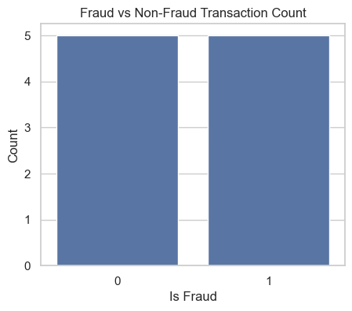

```python
# Simulate the final cleaned DataFrame (simplified for visualization purposes)
df = pd.DataFrame({
    'is_fraud': [0, 1, 0, 1, 0, 1, 1, 0, 0, 1],
    'amt': [10, 200, 50, 300, 60, 400, 250, 70, 90, 150],
    'merchant': ['A', 'B', 'A', 'C', 'A', 'B', 'D', 'A', 'E', 'B'],
    'trans_hour': [9, 15, 12, 22, 13, 18, 21, 10, 14, 23],
    'age': [25, 45, 35, 28, 40, 50, 38, 30, 34, 29],
    'category': ['grocery', 'electronics', 'grocery', 'electronics', 'clothing', 'electronics', 'grocery', 'clothing', 'grocery', 'clothing'],
    'job': ['engineer', 'doctor', 'artist', 'teacher', 'nurse', 'engineer', 'artist', 'doctor', 'nurse', 'teacher'],
    'city_pop': [50000, 100000, 30000, 75000, 60000, 100000, 40000, 50000, 30000, 75000],
    'lat': [3.1, 3.2, 3.3, 3.4, 3.5, 3.6, 3.7, 3.1, 3.2, 3.3],
    'long': [101.7, 101.6, 101.5, 101.4, 101.3, 101.2, 101.1, 101.0, 100.9, 100.8]
})

# Set plot style
sns.set(style="whitegrid")

# 1. Fraud distribution
plt.figure(figsize=(5, 4))
sns.countplot(data=df, x='is_fraud')
plt.title("Fraud vs Non-Fraud Transaction Count")
plt.xlabel("Is Fraud")
plt.ylabel("Count")
plt.show()
```

## 2. Transaction Amount Distribution by Fraud

##### 🔍 Why it matters:

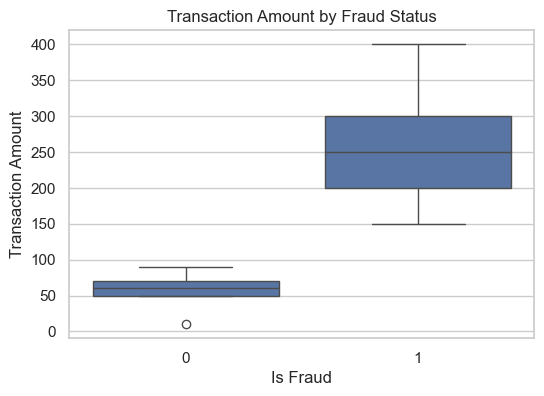

```python
# Simulate the final cleaned DataFrame (simplified for visualization purposes)
df = pd.DataFrame({
    'is_fraud': [0, 1, 0, 1, 0, 1, 1, 0, 0, 1],
    'amt': [10, 200, 50, 300, 60, 400, 250, 70, 90, 150],
    'merchant': ['A', 'B', 'A', 'C', 'A', 'B', 'D', 'A', 'E', 'B'],
    'trans_hour': [9, 15, 12, 22, 13, 18, 21, 10, 14, 23],
    'age': [25, 45, 35, 28, 40, 50, 38, 30, 34, 29],
    'category': ['grocery', 'electronics', 'grocery', 'electronics', 'clothing', 'electronics', 'grocery', 'clothing', 'grocery', 'clothing'],
    'job': ['engineer', 'doctor', 'artist', 'teacher', 'nurse', 'engineer', 'artist', 'doctor', 'nurse', 'teacher'],
    'city_pop': [50000, 100000, 30000, 75000, 60000, 100000, 40000, 50000, 30000, 75000],
    'lat': [3.1, 3.2, 3.3, 3.4, 3.5, 3.6, 3.7, 3.1, 3.2, 3.3],
    'long': [101.7, 101.6, 101.5, 101.4, 101.3, 101.2, 101.1, 101.0, 100.9, 100.8]
})

# Set plot style
sns.set(style="whitegrid")

# 2. Transaction Amount by Fraud
plt.figure(figsize=(6, 4))
sns.boxplot(data=df, x='is_fraud', y='amt')
plt.title("Transaction Amount by Fraud Status")
plt.xlabel("Is Fraud")
plt.ylabel("Transaction Amount")
plt.show()
```

##### 🔍 Why it matters:

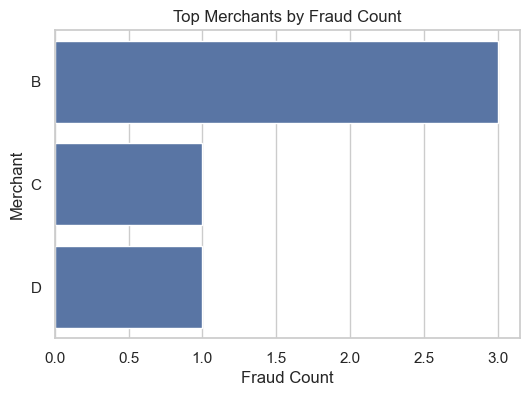

```python
# Simulate the final cleaned DataFrame (simplified for visualization purposes)
df = pd.DataFrame({
    'is_fraud': [0, 1, 0, 1, 0, 1, 1, 0, 0, 1],
    'amt': [10, 200, 50, 300, 60, 400, 250, 70, 90, 150],
    'merchant': ['A', 'B', 'A', 'C', 'A', 'B', 'D', 'A', 'E', 'B'],
    'trans_hour': [9, 15, 12, 22, 13, 18, 21, 10, 14, 23],
    'age': [25, 45, 35, 28, 40, 50, 38, 30, 34, 29],
    'category': ['grocery', 'electronics', 'grocery', 'electronics', 'clothing', 'electronics', 'grocery', 'clothing', 'grocery', 'clothing'],
    'job': ['engineer', 'doctor', 'artist', 'teacher', 'nurse', 'engineer', 'artist', 'doctor', 'nurse', 'teacher'],
    'city_pop': [50000, 100000, 30000, 75000, 60000, 100000, 40000, 50000, 30000, 75000],
    'lat': [3.1, 3.2, 3.3, 3.4, 3.5, 3.6, 3.7, 3.1, 3.2, 3.3],
    'long': [101.7, 101.6, 101.5, 101.4, 101.3, 101.2, 101.1, 101.0, 100.9, 100.8]
})

# Set plot style
sns.set(style="whitegrid")

# 3. Top Merchants by Fraud Cases
fraud_merchants = df[df['is_fraud'] == 1]['merchant'].value_counts().head(5)
plt.figure(figsize=(6, 4))
sns.barplot(x=fraud_merchants.values, y=fraud_merchants.index)
plt.title("Top Merchants by Fraud Count")
plt.xlabel("Fraud Count")
plt.ylabel("Merchant")
plt.show()
```

##### 🔍 Why it matters:

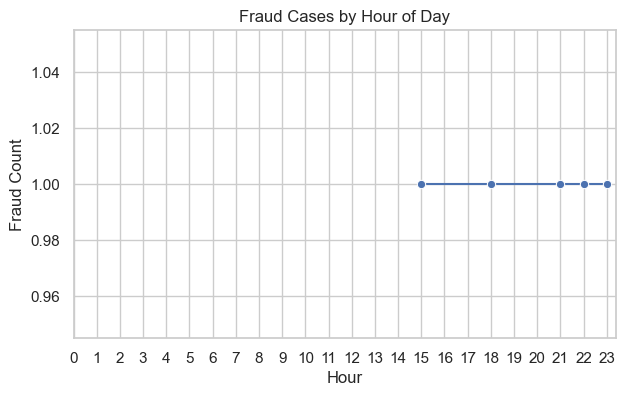

```python
# Simulate the final cleaned DataFrame (simplified for visualization purposes)
df = pd.DataFrame({
    'is_fraud': [0, 1, 0, 1, 0, 1, 1, 0, 0, 1],
    'amt': [10, 200, 50, 300, 60, 400, 250, 70, 90, 150],
    'merchant': ['A', 'B', 'A', 'C', 'A', 'B', 'D', 'A', 'E', 'B'],
    'trans_hour': [9, 15, 12, 22, 13, 18, 21, 10, 14, 23],
    'age': [25, 45, 35, 28, 40, 50, 38, 30, 34, 29],
    'category': ['grocery', 'electronics', 'grocery', 'electronics', 'clothing', 'electronics', 'grocery', 'clothing', 'grocery', 'clothing'],
    'job': ['engineer', 'doctor', 'artist', 'teacher', 'nurse', 'engineer', 'artist', 'doctor', 'nurse', 'teacher'],
    'city_pop': [50000, 100000, 30000, 75000, 60000, 100000, 40000, 50000, 30000, 75000],
    'lat': [3.1, 3.2, 3.3, 3.4, 3.5, 3.6, 3.7, 3.1, 3.2, 3.3],
    'long': [101.7, 101.6, 101.5, 101.4, 101.3, 101.2, 101.1, 101.0, 100.9, 100.8]
})

# Set plot style
sns.set(style="whitegrid")

# 4. Fraud by Hour
hourly_fraud = df[df['is_fraud'] == 1]['trans_hour'].value_counts().sort_index()
plt.figure(figsize=(7, 4))
sns.lineplot(x=hourly_fraud.index, y=hourly_fraud.values, marker='o')
plt.title("Fraud Cases by Hour of Day")
plt.xlabel("Hour")
plt.ylabel("Fraud Count")
plt.xticks(range(0, 24))
plt.show()
```

## 5. Age Distribution of Customers

##### 📊 What it shows:

The distribution of customer ages involved in both fraudulent and non-fraudulent transactions.

##### 🔍 Why it matters:

Helps identify which age groups are more frequently targeted or involved in fraud. This can inform risk models, targeted education, or fraud prevention strategies for vulnerable age groups.

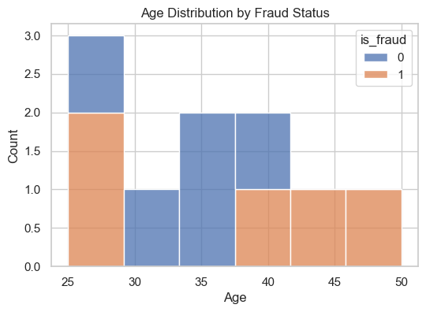

```python
# Simulate the final cleaned DataFrame (simplified for visualization purposes)
df = pd.DataFrame({
    'is_fraud': [0, 1, 0, 1, 0, 1, 1, 0, 0, 1],
    'amt': [10, 200, 50, 300, 60, 400, 250, 70, 90, 150],
    'merchant': ['A', 'B', 'A', 'C', 'A', 'B', 'D', 'A', 'E', 'B'],
    'trans_hour': [9, 15, 12, 22, 13, 18, 21, 10, 14, 23],
    'age': [25, 45, 35, 28, 40, 50, 38, 30, 34, 29],
    'category': ['grocery', 'electronics', 'grocery', 'electronics', 'clothing', 'electronics', 'grocery', 'clothing', 'grocery', 'clothing'],
    'job': ['engineer', 'doctor', 'artist', 'teacher', 'nurse', 'engineer', 'artist', 'doctor', 'nurse', 'teacher'],
    'city_pop': [50000, 100000, 30000, 75000, 60000, 100000, 40000, 50000, 30000, 75000],
    'lat': [3.1, 3.2, 3.3, 3.4, 3.5, 3.6, 3.7, 3.1, 3.2, 3.3],
    'long': [101.7, 101.6, 101.5, 101.4, 101.3, 101.2, 101.1, 101.0, 100.9, 100.8]
})

# Set plot style
sns.set(style="whitegrid")

# 5. Age vs Fraud Trend
plt.figure(figsize=(6, 4))
sns.histplot(data=df, x='age', hue='is_fraud', multiple='stack', bins=6)
plt.title("Age Distribution by Fraud Status")
plt.xlabel("Age")
plt.ylabel("Count")
plt.show()
```

## 6. Fraud Rate by Merchant Category

##### 📊 What it shows:

Which merchant categories have the highest fraud rate.

##### 🔍 Why it matters:

Some categories may be more prone to fraud (e.g. online shopping, travel).

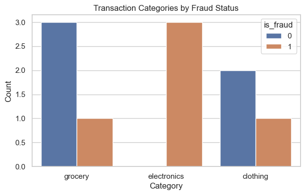

```python
# Simulate the final cleaned DataFrame (simplified for visualization purposes)
df = pd.DataFrame({
    'is_fraud': [0, 1, 0, 1, 0, 1, 1, 0, 0, 1],
    'amt': [10, 200, 50, 300, 60, 400, 250, 70, 90, 150],
    'merchant': ['A', 'B', 'A', 'C', 'A', 'B', 'D', 'A', 'E', 'B'],
    'trans_hour': [9, 15, 12, 22, 13, 18, 21, 10, 14, 23],
    'age': [25, 45, 35, 28, 40, 50, 38, 30, 34, 29],
    'category': ['grocery', 'electronics', 'grocery', 'electronics', 'clothing', 'electronics', 'grocery', 'clothing', 'grocery', 'clothing'],
    'job': ['engineer', 'doctor', 'artist', 'teacher', 'nurse', 'engineer', 'artist', 'doctor', 'nurse', 'teacher'],
    'city_pop': [50000, 100000, 30000, 75000, 60000, 100000, 40000, 50000, 30000, 75000],
    'lat': [3.1, 3.2, 3.3, 3.4, 3.5, 3.6, 3.7, 3.1, 3.2, 3.3],
    'long': [101.7, 101.6, 101.5, 101.4, 101.3, 101.2, 101.1, 101.0, 100.9, 100.8]
})

# Set plot style
sns.set(style="whitegrid")

# 6. Category vs Fraud Count
plt.figure(figsize=(7, 4))
sns.countplot(data=df, x='category', hue='is_fraud')
plt.title("Transaction Categories by Fraud Status")
plt.xlabel("Category")
plt.ylabel("Count")
plt.show()
```

## 7. Fraud cases by job Type

##### 📊 What it shows:

Which professions have higher fraud rates.

##### 🔍 Why it matters:

This could guide targeted fraud detection rules or profile analysis.

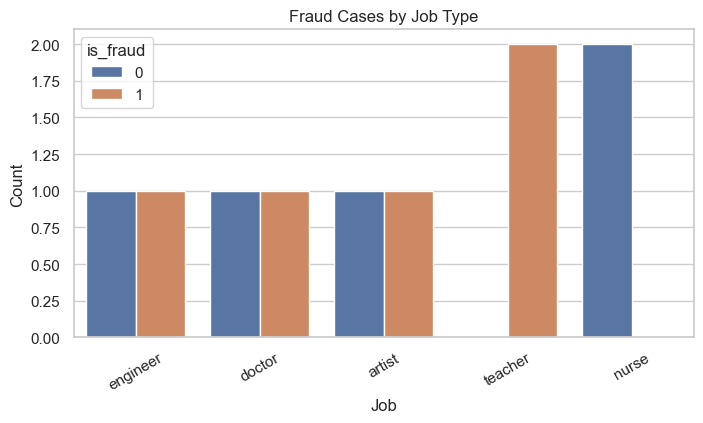

```python
# Simulate the final cleaned DataFrame (simplified for visualization purposes)
df = pd.DataFrame({
    'is_fraud': [0, 1, 0, 1, 0, 1, 1, 0, 0, 1],
    'amt': [10, 200, 50, 300, 60, 400, 250, 70, 90, 150],
    'merchant': ['A', 'B', 'A', 'C', 'A', 'B', 'D', 'A', 'E', 'B'],
    'trans_hour': [9, 15, 12, 22, 13, 18, 21, 10, 14, 23],
    'age': [25, 45, 35, 28, 40, 50, 38, 30, 34, 29],
    'category': ['grocery', 'electronics', 'grocery', 'electronics', 'clothing', 'electronics', 'grocery', 'clothing', 'grocery', 'clothing'],
    'job': ['engineer', 'doctor', 'artist', 'teacher', 'nurse', 'engineer', 'artist', 'doctor', 'nurse', 'teacher'],
    'city_pop': [50000, 100000, 30000, 75000, 60000, 100000, 40000, 50000, 30000, 75000],
    'lat': [3.1, 3.2, 3.3, 3.4, 3.5, 3.6, 3.7, 3.1, 3.2, 3.3],
    'long': [101.7, 101.6, 101.5, 101.4, 101.3, 101.2, 101.1, 101.0, 100.9, 100.8]
})

# Set plot style
sns.set(style="whitegrid")

# 7. Job vs Fraud Count
plt.figure(figsize=(8, 4))
sns.countplot(data=df, x='job', hue='is_fraud')
plt.title("Fraud Cases by Job Type")
plt.xlabel("Job")
plt.ylabel("Count")
plt.xticks(rotation=30)
plt.show()
```

## 8. City Population and fraud count

##### 📊 What it shows:

This scatterplot displays fraudulent transactions by plotting the city population on the x-axis against the transaction amount on the y-axis. Each point represents a fraudulent transaction, and the points are color-coded by the customer's job type.

##### 🔍 Why it matters:

It helps identify if fraud occurs more frequently in cities of certain sizes and whether transaction amounts vary with city population.

The job-based color coding can reveal if specific professions are more involved in higher-value frauds in cities of different population sizes.

This insight supports targeting fraud detection efforts geographically and demographically, allowing for tailored risk management.

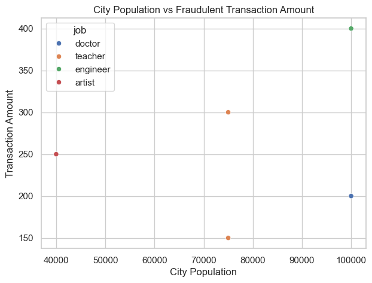

```python
# Simulate the final cleaned DataFrame (simplified for visualization purposes)
df = pd.DataFrame({
    'is_fraud': [0, 1, 0, 1, 0, 1, 1, 0, 0, 1],
    'amt': [10, 200, 50, 300, 60, 400, 250, 70, 90, 150],
    'merchant': ['A', 'B', 'A', 'C', 'A', 'B', 'D', 'A', 'E', 'B'],
    'trans_hour': [9, 15, 12, 22, 13, 18, 21, 10, 14, 23],
    'age': [25, 45, 35, 28, 40, 50, 38, 30, 34, 29],
    'category': ['grocery', 'electronics', 'grocery', 'electronics', 'clothing', 'electronics', 'grocery', 'clothing', 'grocery', 'clothing'],
    'job': ['engineer', 'doctor', 'artist', 'teacher', 'nurse', 'engineer', 'artist', 'doctor', 'nurse', 'teacher'],
    'city_pop': [50000, 100000, 30000, 75000, 60000, 100000, 40000, 50000, 30000, 75000],
    'lat': [3.1, 3.2, 3.3, 3.4, 3.5, 3.6, 3.7, 3.1, 3.2, 3.3],
    'long': [101.7, 101.6, 101.5, 101.4, 101.3, 101.2, 101.1, 101.0, 100.9, 100.8]
})

# Set plot style
sns.set(style="whitegrid")

# 8. City Population vs Fraud Count
plt.figure(figsize=(7, 5))
sns.scatterplot(data=df[df['is_fraud'] == 1], x='city_pop', y='amt', hue='job', palette='deep')
plt.title("City Population vs Fraudulent Transaction Amount")
plt.xlabel("City Population")
plt.ylabel("Transaction Amount")
plt.show()
```

##### 🔍 Why it matters:

Useful for regional fraud analysis or understanding market activity.

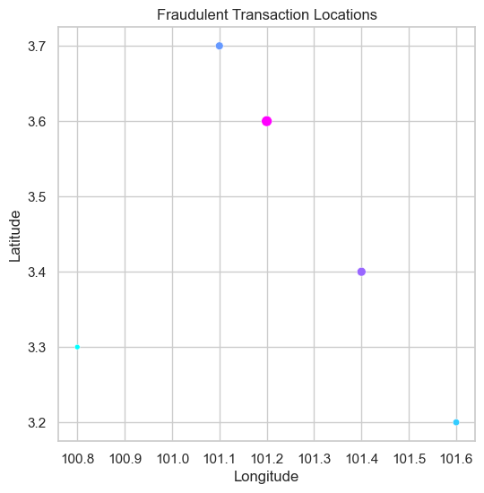

```python
# Simulate the final cleaned DataFrame (simplified for visualization purposes)
df = pd.DataFrame({
    'is_fraud': [0, 1, 0, 1, 0, 1, 1, 0, 0, 1],
    'amt': [10, 200, 50, 300, 60, 400, 250, 70, 90, 150],
    'merchant': ['A', 'B', 'A', 'C', 'A', 'B', 'D', 'A', 'E', 'B'],
    'trans_hour': [9, 15, 12, 22, 13, 18, 21, 10, 14, 23],
    'age': [25, 45, 35, 28, 40, 50, 38, 30, 34, 29],
    'category': ['grocery', 'electronics', 'grocery', 'electronics', 'clothing', 'electronics', 'grocery', 'clothing', 'grocery', 'clothing'],
    'job': ['engineer', 'doctor', 'artist', 'teacher', 'nurse', 'engineer', 'artist', 'doctor', 'nurse', 'teacher'],
    'city_pop': [50000, 100000, 30000, 75000, 60000, 100000, 40000, 50000, 30000, 75000],
    'lat': [3.1, 3.2, 3.3, 3.4, 3.5, 3.6, 3.7, 3.1, 3.2, 3.3],
    'long': [101.7, 101.6, 101.5, 101.4, 101.3, 101.2, 101.1, 101.0, 100.9, 100.8]
})

# Set plot style
sns.set(style="whitegrid")

# 9. Fraud Location Heatmap
plt.figure(figsize=(6, 6))
sns.scatterplot(data=df[df['is_fraud'] == 1], x='long', y='lat', size='amt', hue='amt', palette='cool', legend=False)
plt.title("Fraudulent Transaction Locations")
plt.xlabel("Longitude")
plt.ylabel("Latitude")
plt.show()
```

## 10. Feature Engineering

```python
# Transaction velocity: count of transactions per customer per hour (simulate customer_id)
df['customer_id'] = ['cust1', 'cust2', 'cust1', 'cust3', 'cust2', 'cust1', 'cust3', 'cust2', 'cust1', 'cust3']

# Transactions per customer per hour
df['trans_hour'] = df['trans_hour'].astype(int)
df['transactions_per_hour'] = df.groupby(['customer_id', 'trans_hour'])['amt'].transform('count')

# Amount relative to customer's average
df['avg_amt_per_customer'] = df.groupby('customer_id')['amt'].transform('mean')
df['amt_relative_to_avg'] = df['amt'] / df['avg_amt_per_customer']

# Time since last transaction per customer (simulate transaction timestamp)
df['timestamp'] = pd.date_range(start='2025-01-01', periods=len(df), freq='h')
df = df.sort_values(['customer_id', 'timestamp'])
df['time_since_last_trans'] = df.groupby('customer_id')['timestamp'].diff().dt.total_seconds().fillna(0)

df[['customer_id', 'trans_hour', 'transactions_per_hour', 'amt', 'avg_amt_per_customer', 'amt_relative_to_avg', 'time_since_last_trans']]
```

|  | customer_id | trans_hour | transactions_per_hour | amt | avg_amt_per_customer | amt_relative_to_avg | time_since_last_trans |
| --- | --- | --- | --- | --- | --- | --- | --- |
| 0 | cust1 | 9 | 1 | 10 | 137.500000 | 0.072727 | 0.0 |
| 2 | cust1 | 12 | 1 | 50 | 137.500000 | 0.363636 | 7200.0 |
| 5 | cust1 | 18 | 1 | 400 | 137.500000 | 2.909091 | 10800.0 |
| 8 | cust1 | 14 | 1 | 90 | 137.500000 | 0.654545 | 10800.0 |
| 1 | cust2 | 15 | 1 | 200 | 110.000000 | 1.818182 | 0.0 |
| 4 | cust2 | 13 | 1 | 60 | 110.000000 | 0.545455 | 10800.0 |
| 7 | cust2 | 10 | 1 | 70 | 110.000000 | 0.636364 | 10800.0 |
| 3 | cust3 | 22 | 1 | 300 | 233.333333 | 1.285714 | 0.0 |
| 6 | cust3 | 21 | 1 | 250 | 233.333333 | 1.071429 | 10800.0 |
| 9 | cust3 | 23 | 1 | 150 | 233.333333 | 0.642857 | 10800.0 |

## 11. Correlation Analysis

##### Purpose:

To identify relationships between different numeric features (e.g., transaction amount, customer age, transaction hour) and see how they relate to fraud or each other.

What it tells us:

Which features move together (positive or negative correlation).

Which features might be redundant or highly influential for fraud detection.

Helps select relevant features for modeling and understanding underlying patterns.

##### Example insight:

If transaction amount is strongly correlated with fraud, high-value transactions might require closer scrutiny.

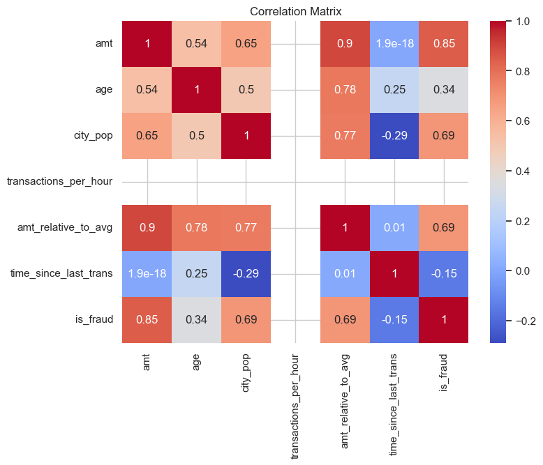

```python
# Correlation matrix for numeric features
numeric_cols = ['amt', 'age', 'city_pop', 'transactions_per_hour', 'amt_relative_to_avg', 'time_since_last_trans']
corr = df[numeric_cols + ['is_fraud']].corr()

plt.figure(figsize=(8,6))
sns.heatmap(corr, annot=True, cmap='coolwarm')
plt.title("Correlation Matrix")
plt.show()
```

## 12. Customer Segmentation (Clustering Example)

##### Purpose:

Group customers based on transaction behavior or demographics without predefined labels.

What it tells us:

Reveals distinct customer groups with similar behaviors (e.g., high spenders, frequent small transactions).

Helps tailor fraud detection strategies or marketing by segment.

Can uncover unusual clusters that may indicate fraud rings or anomalies.

##### Example insight:

A cluster of customers who perform transactions mostly at odd hours could be flagged for further investigation.

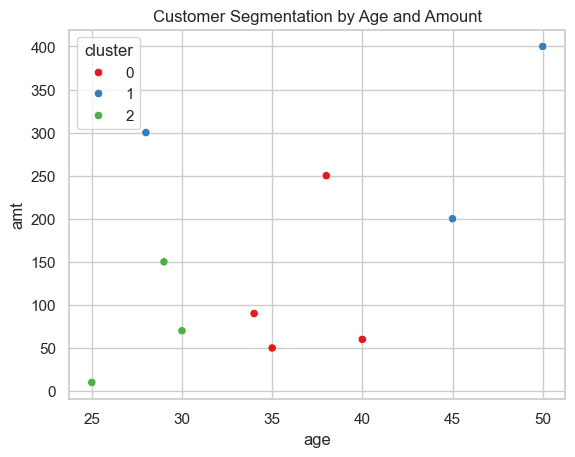

```python
from sklearn.preprocessing import StandardScaler
from sklearn.cluster import KMeans

# Use selected features for clustering
features = ['amt', 'age', 'city_pop']

scaler = StandardScaler()
X_scaled = scaler.fit_transform(df[features])

kmeans = KMeans(n_clusters=3, random_state=42)
df['cluster'] = kmeans.fit_predict(X_scaled)

# Plot clusters
sns.scatterplot(data=df, x='age', y='amt', hue='cluster', palette='Set1')
plt.title("Customer Segmentation by Age and Amount")
plt.show()
```

## 13. Time Series & Trend Analysis

##### Purpose:

Analyze transaction patterns over time to detect seasonality, spikes, or anomalies.

What it tells us:

How fraud rates fluctuate by time of day, day of week, or month.

Detects unusual transaction bursts or drops that might signal fraud campaigns.

Helps in setting dynamic thresholds and alerts.

##### Example insight:

Fraud cases spike during certain hours (e.g., late night), indicating risk periods needing heightened monitoring.

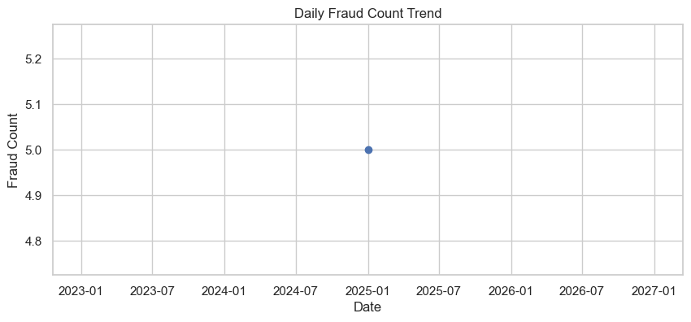

```python
# Fraud counts by date or hour (assuming timestamp column)
df['date'] = df['timestamp'].dt.date
fraud_daily = df[df['is_fraud'] == 1].groupby('date').size()

plt.figure(figsize=(10,4))
fraud_daily.plot(kind='line', marker='o')
plt.title("Daily Fraud Count Trend")
plt.xlabel("Date")
plt.ylabel("Fraud Count")
plt.show()
```

## 14. Geospatial Clustering (DBSCAN)

##### Purpose:

Identify clusters of transactions based on location data (latitude and longitude) to find patterns or anomalies.

What it tells us:

Usual geographic areas for customers’ transactions.

Outliers or clusters indicating unusual transaction locations (potential fraud).

Fraudulent transactions occurring in unexpected locations.

##### Example insight:

Transactions for a single customer in geographically distant places within a short time window suggest stolen card use.

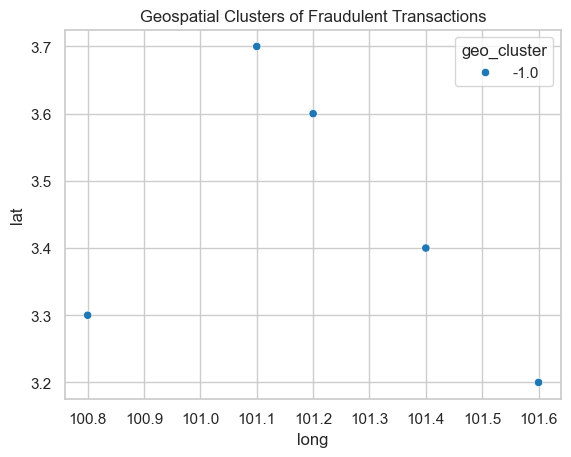

```python
from sklearn.cluster import DBSCAN

coords = df[df['is_fraud'] == 1][['lat', 'long']].values

# DBSCAN with eps in approx degrees (0.01 ~1km)
db = DBSCAN(eps=0.01, min_samples=2).fit(coords)
df.loc[df['is_fraud'] == 1, 'geo_cluster'] = db.labels_

sns.scatterplot(data=df[df['is_fraud'] == 1], x='long', y='lat', hue='geo_cluster', palette='tab10')
plt.title("Geospatial Clusters of Fraudulent Transactions")
plt.show()
```

## 15. Outlier Detection with Isolation Forest

##### Purpose:

Automatically identify transactions that differ significantly from normal patterns.

What it tells us:

Flags unusual transactions that could be fraudulent or errors.

Helps prioritize cases for manual review.

Detects anomalies that other models might miss.

##### Example insight:

A transaction with an unusually high amount or abnormal merchant category might be isolated as suspicious.

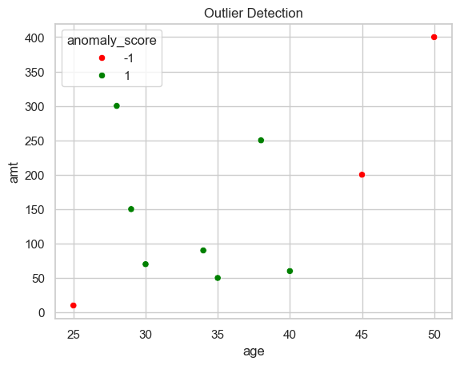

```python
from sklearn.ensemble import IsolationForest

iso = IsolationForest(contamination=0.3, random_state=42)
features = ['amt', 'age', 'city_pop']
X = df[features]

df['anomaly_score'] = iso.fit_predict(X)
# -1 means outlier (potential fraud), 1 means inlier

sns.scatterplot(data=df, x='age', y='amt', hue='anomaly_score', palette=['red', 'green'])
plt.title("Outlier Detection")
plt.show()
```

## 16. Simple Fraud Prediction Model (Logistic Regression)

##### Purpose:

Build a supervised model to predict the probability of a transaction being fraudulent based on features.

What it tells us:

Provides fraud likelihood scores for new transactions.

Identifies key predictors of fraud through model coefficients.

Supports automated fraud detection and prevention.

##### Example insight:

The model predicts that transactions above a certain amount, occurring late at night, have a higher risk of fraud.

```python
from sklearn.model_selection import train_test_split
from sklearn.linear_model import LogisticRegression
from sklearn.metrics import classification_report, roc_auc_score

# Prepare features and target
X = df[['amt', 'age', 'city_pop', 'transactions_per_hour', 'amt_relative_to_avg', 'time_since_last_trans']].fillna(0)
y = df['is_fraud']

X_train, X_test, y_train, y_test = train_test_split(X, y, test_size=0.3, random_state=42)

model = LogisticRegression(max_iter=1000, class_weight='balanced')
model.fit(X_train, y_train)
y_pred = model.predict(X_test)
y_prob = model.predict_proba(X_test)[:, 1]

print(classification_report(y_test, y_pred, zero_division=0))
print("ROC AUC:", roc_auc_score(y_test, y_prob))
```

```
              precision    recall  f1-score   support

           0       0.67      1.00      0.80         2
           1       0.00      0.00      0.00         1

    accuracy                           0.67         3
   macro avg       0.33      0.50      0.40         3
weighted avg       0.44      0.67      0.53         3

ROC AUC: 0.5
```